# Final Project 131

2022-11-27

# Question 1:

#### Dimensions of election.raw:

```
## [1] 32177     5
```

#### How many NA values are in election.raw:

```
## [1] 0
```

#### Number of unique states:

```
## [1] 51
```

The data contains 50 states and the District of Columbia.

# Question 2:

```
## [1] 3220   37
```

#### How many NA values in Census:

```
## [1] 1
```

#### Number of distinct counties in census:

```
## [1] 3220
```

#### Number of distinct counties in election.raw:

```
## [1] 2825
```

There is a lower number of unique counties in election.raw than in the census dataset, which could mean that some counties were not included in the election.

# Question 3:

#### Display head of election.state:

```
## # A tibble: 6 × 3
## # Groups:   state [2]
##   state   candidate             n
##   <chr>   <fct>             <dbl>
## 1 Alabama Donald Trump    1441168
## 2 Alabama Jo Jorgensen      25176
## 3 Alabama Joe Biden        849648
## 4 Alabama Write-ins          7312
## 5 Alaska  Brock Pierce        825
## 6 Alaska  Don Blankenship    1127
```

#### Display head of election.total:

```
## # A tibble: 6 × 2
##   candidate          n
##   <fct>          <dbl>
## 1 Alyson Kennedy  6791
## 2 Bill Hammons    6647
## 3 Blake Huber      409
## 4 Brian Carroll  25256
## 5 Brock Pierce   49552
## 6 Brooke Paige    1175
```

# Question 4:

#### Number of presidential candidates in the 2020 election:

```r
length(unique(election.raw$candidate))
```

```
## [1] 38
```

#### Display Barchart for each Candidate’s Total Votes:

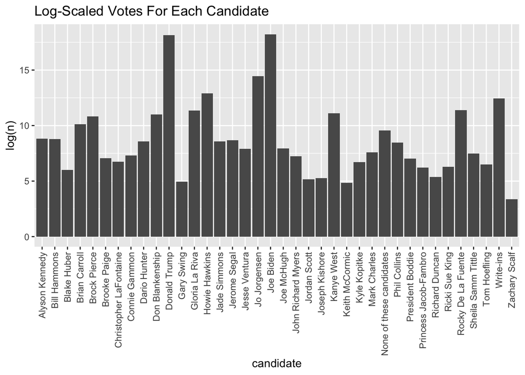

# Question 5:

#### Display head of county.winner:

```
## # A tibble: 6 × 6
## # Groups:   state, county [6]
##   state   county  candidate      pct   tot party
##   <chr>   <chr>   <fct>        <dbl> <dbl> <fct>
## 1 Alabama Autauga Donald Trump 0.714 19838 REP
## 2 Alabama Baldwin Donald Trump 0.762 83544 REP
## 3 Alabama Barbour Donald Trump 0.535  5622 REP
## 4 Alabama Bibb    Donald Trump 0.784  7525 REP
## 5 Alabama Blount  Donald Trump 0.896 24711 REP
## 6 Alabama Bullock Joe Biden    0.747  3446 DEM
```

#### Display head of state.winner:

```
## # A tibble: 6 × 3
## # Groups:   state [6]
##   state      candidate      pct
##   <chr>      <fct>        <dbl>
## 1 Alabama    Donald Trump 0.620
## 2 Alaska     Donald Trump 0.485
## 3 Arizona    Joe Biden    0.494
## 4 Arkansas   Donald Trump 0.624
## 5 California Joe Biden    0.635
## 6 Colorado   Joe Biden    0.554
```

# Question 6:

#### Display Each County In the US

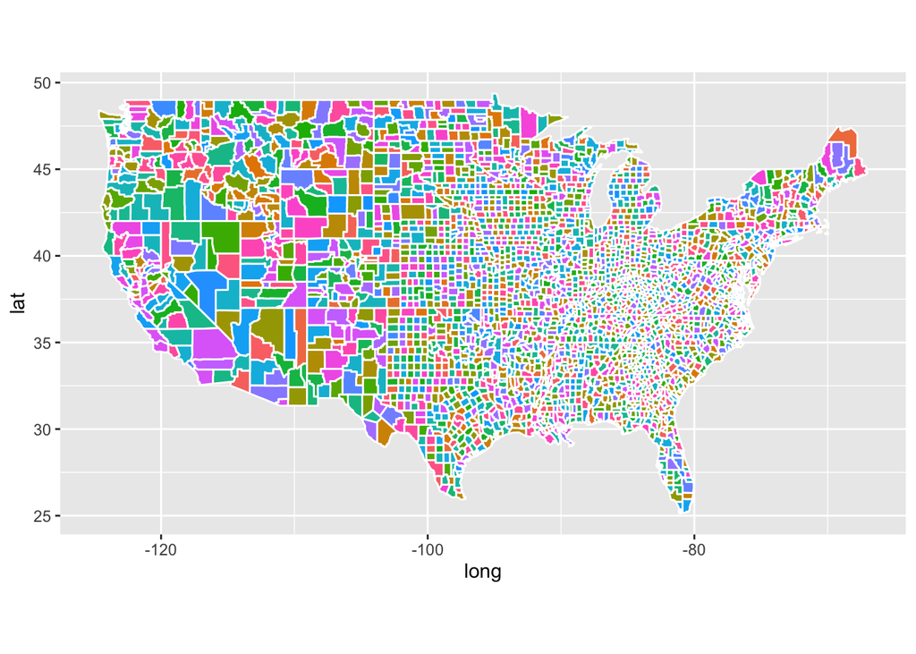

# Question 7:

#### Display the Colored Map of the Winner of Each State

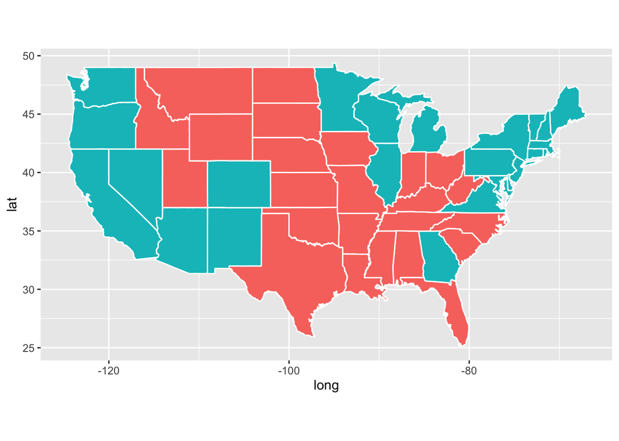

Biden is colored as light blue, while Trump is colored as red.

# Question 8:

#### Display the Colored Map of the Winner of Each California County

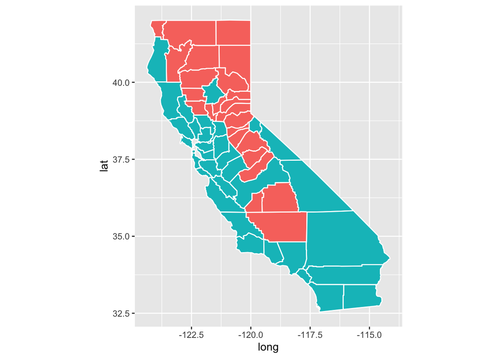

Biden represents the light blue, while Trump represents red.

# Question 9:

#### Displaying a Visual for the Census Data:

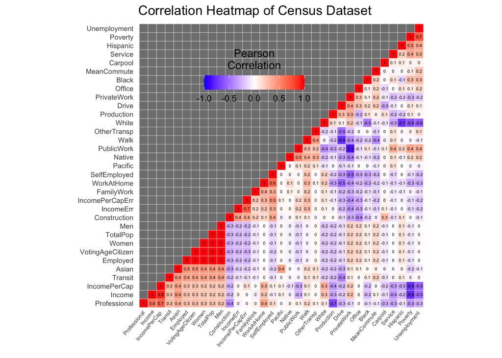

# Question 10:

#### Display the First 5 Rows of census.clean:

```
##   CountyId   State         County TotalPop       Men  Women White
## 1     1001 Alabama Autauga County    55036 0.4887528  28137  75.4
## 2     1003 Alabama Baldwin County   203360 0.4894129 103833  83.1
## 3     1005 Alabama Barbour County    26201 0.5334148  12225  45.7
## 4     1007 Alabama    Bibb County    22580 0.5425598  10329  74.6
## 5     1009 Alabama  Blount County    57667 0.4940434  29177  87.4
##   VotingAgeCitizen Income Poverty ChildPoverty Professional Service Office
## 1        0.7452576  55317    13.7         20.1         35.3    18.0   23.2
## 2        0.7640441  52562    11.8         16.1         35.7    18.2   25.6
## 3        0.7735964  33368    27.2         44.9         25.0    16.8   22.6
## 4        0.7821966  43404    15.2         26.6         24.4    17.6   19.7
## 5        0.7372154  47412    15.6         25.4         28.5    12.9   23.3
##   Production Drive Carpool Transit OtherTransp WorkAtHome MeanCommute  Employed
## 1       15.4  86.0     9.6     0.1         1.3        2.5        25.8 0.4381132
## 2       10.8  84.7     7.6     0.1         1.1        5.6        27.0 0.4402390
## 3       24.1  83.4    11.1     0.3         1.7        1.3        23.4 0.3388420
## 4       22.4  86.4     9.5     0.7         1.7        1.5        30.0 0.3618689
## 5       19.5  86.8    10.2     0.1         0.4        2.1        35.0 0.3707493
##   PrivateWork SelfEmployed FamilyWork Unemployment Minority
## 1        74.1          5.6        0.1          5.2     22.8
## 2        80.7          6.3        0.1          5.5     15.4
## 3        74.1          6.5        0.3         12.4     52.8
## 4        76.0          6.3        0.3          8.2     24.8
## 5        83.9          4.0        0.1          4.9     10.9
```

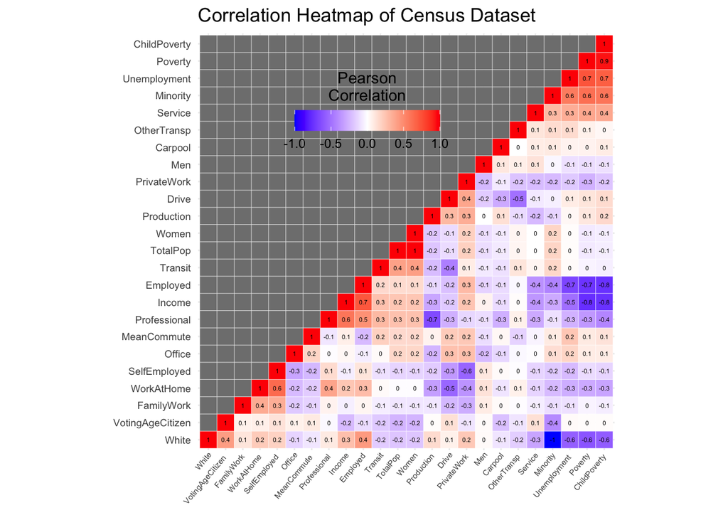

Using the correlation matrix, we see that we have one perfect colinearity between White and Minority. Therefore, we can take out the white variable.

# Question 11:

I did both centering and scaling for PCA. In terms of centering, we should center because centering is required in order to perform PCA. In terms of scaling, Since most of the data points have vastly different means and variances, we can perform PCA with scaled values.

Top 3 largest absolute values of PC1:

```
##                    PC1
## ChildPoverty 0.3895535
## Poverty      0.3871282
## Employed     0.3721068
```

# Question 12:

```
##  [1] 0.2195560 0.3558879 0.4818307 0.5547350 0.6087571 0.6579658 0.7033740
##  [8] 0.7460702 0.7841610 0.8195951 0.8515675 0.8820195 0.9058760 0.9278966
## [15] 0.9450450 0.9583440 0.9697417 0.9788285 0.9859610 0.9913343 0.9952680
## [22] 0.9982103 0.9999966 1.0000000
```

The minimum number of PCs needed to capture 90% of the variance for the analysis is 13.

#### PVE Plot

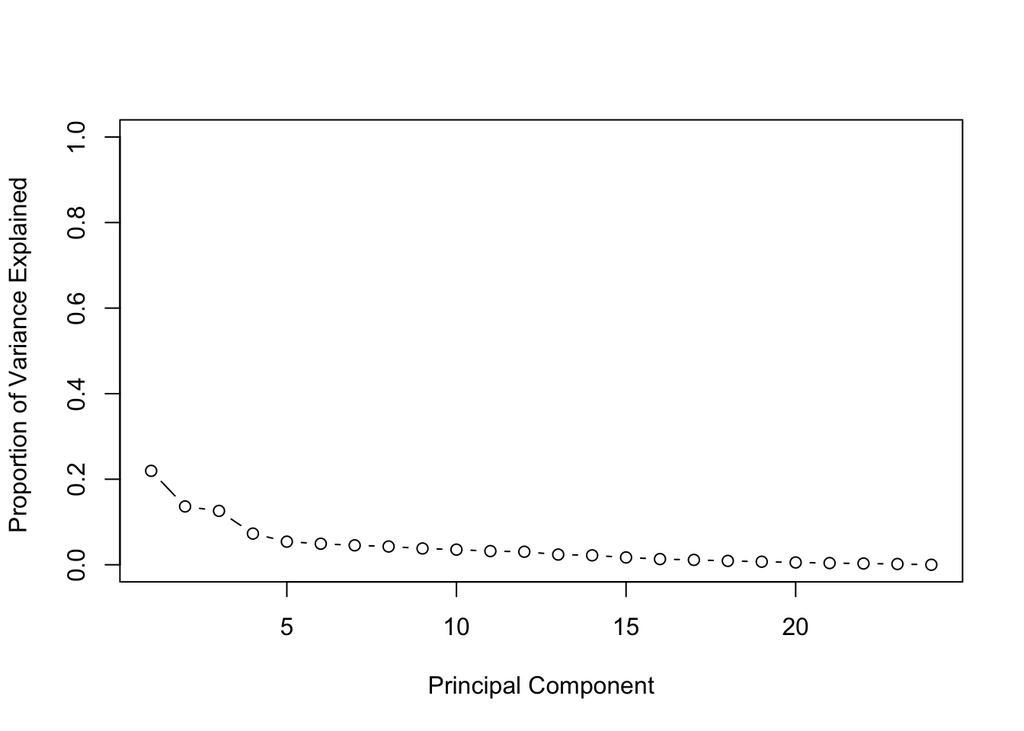

#### Cumulative PVE Plot

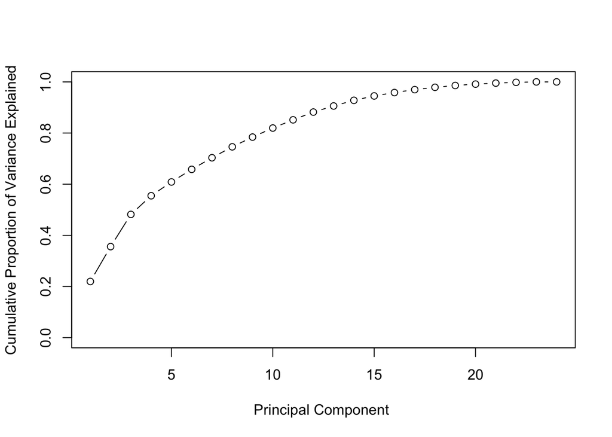

# Question 13:

#### Cluster for the census.clean dataset:

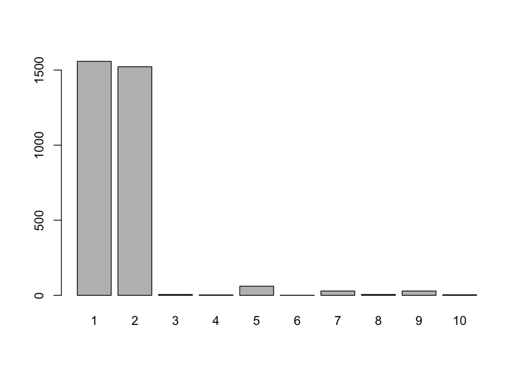

#### Cluster for the first 2 PCs dataset

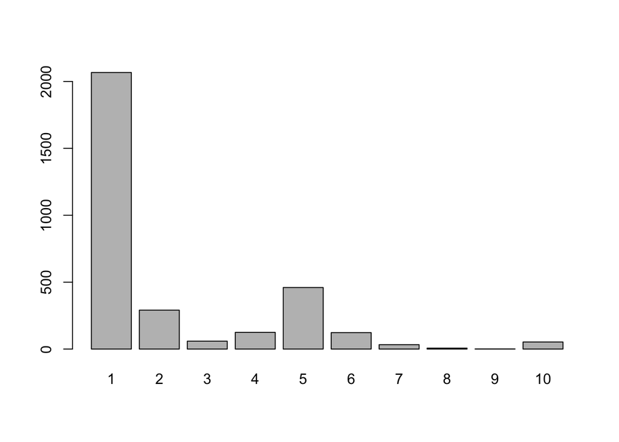

Our census.clean cluster has 2 highly voted equal county winners, with not many candidates winning many counties. Our pc cluster, however, has 1 clear majority county winner, with a large gap between the others. However, 2 and 5 have a lot of county winners. Neither plots make very much sense, unless Trump and Biden won a similar amount of counties for the first plot or there was another candidate who won lots of counties in the second plot.

#### Investigating Cluster containing SB County

```r
# Census cluster in SB county
print(census.clus[228])
```

```
## [1] 2
```

```r
# PC cluster in SB county
print(pc.clus[228])
```

```
## [1] 1
```

When we see the clustering, SB county is placed more appropriately in the census cluster since we mainly just want two clusters with a lot of observations since there were mainly just 2 candidates who won every county. So PC clustering wouldn’t make much sense because there are more than 2 candidates winning each county.

# Question 14:

We need to exclude the predictor party from election.cl since it’s perfectly colinear with the candidate. The candidate and the party will always be the same relation no matter what. Therefore, it will not only be bad for our machine learning methods, but they are also redundant and take up computational time.

# Question 15:

#### Visualizing pre-pruned tree

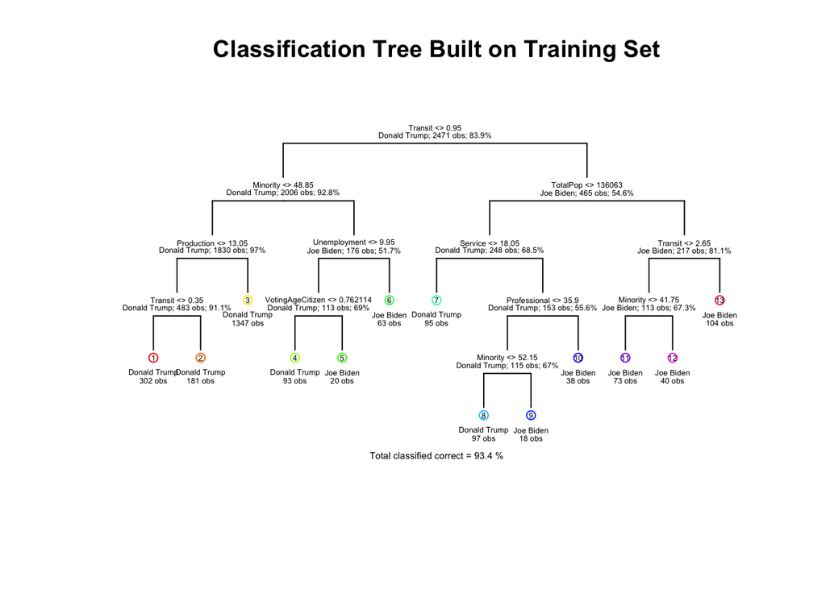

#### Visualizing the Pruned Tree

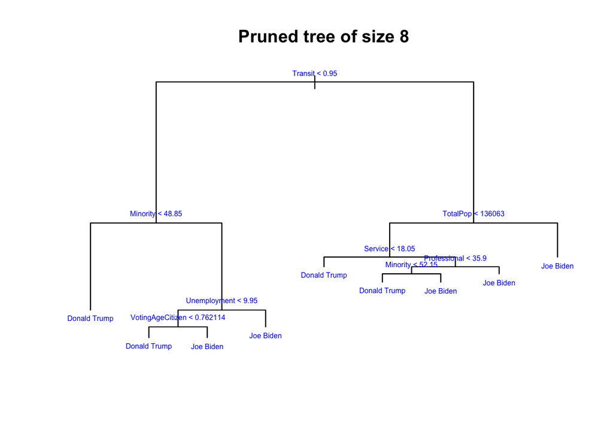

Using the pruned plot, we get a similar error rate to the decision tree but with much smaller size and lesser overfitting. The pruned tree is also much easier to interpret.

# Question 16:

```
##
## Call:
## glm(formula = candidate ~ ., family = binomial, data = election.cl[idx.tr,
##     ])
##
## Deviance Residuals:
##     Min       1Q   Median       3Q      Max
## -2.7574  -0.2345  -0.0955  -0.0326   3.3515
##
## Coefficients:
##                      Estimate   Std. Error z value             Pr(>|z|)
## (Intercept)      -46.27071898   6.49489383  -7.124 0.000000000001047108 ***
## TotalPop           0.00002957   0.00003046   0.971             0.331631
## Men               -0.02115421   4.89708653  -0.004             0.996553
## Women             -0.00005551   0.00005983  -0.928             0.353487
## VotingAgeCitizen  16.02865682   2.56292677   6.254 0.000000000399958200 ***
## Income            -0.00001203   0.00001589  -0.757             0.448813
## Poverty            0.02781443   0.04056867   0.686             0.492957
## ChildPoverty       0.00478902   0.02354077   0.203             0.838795
## Professional       0.31312059   0.03864751   8.102 0.000000000000000541 ***
## Service            0.33253935   0.04435588   7.497 0.000000000000065258 ***
## Office             0.17467435   0.04615592   3.784             0.000154 ***
## Production         0.19134084   0.03917155   4.885 0.000001035923631693 ***
## Drive             -0.14058453   0.03538674  -3.973 0.000071031907678005 ***
## Carpool           -0.09978044   0.04912908  -2.031             0.042256 *
## Transit            0.27599284   0.08798227   3.137             0.001707 **
## OtherTransp        0.13903843   0.09194993   1.512             0.130506
## WorkAtHome        -0.00340016   0.06459919  -0.053             0.958023
## MeanCommute        0.02114094   0.02284194   0.926             0.354689
## Employed          25.69092030   3.22828963   7.958 0.000000000000001748 ***
## PrivateWork        0.05132459   0.02137367   2.401             0.016337 *
## SelfEmployed      -0.01789962   0.04648259  -0.385             0.700177
## FamilyWork        -0.64876518   0.30499713  -2.127             0.033410 *
## Unemployment       0.28941359   0.04808066   6.019 0.000000001751350561 ***
## Minority           0.12420385   0.00954414  13.014 < 0.0000000000000002 ***
## ---
## Signif. codes:  0 '***' 0.001 '**' 0.01 '*' 0.05 '.' 0.1 ' ' 1
##
## (Dispersion parameter for binomial family taken to be 1)
##
##     Null deviance: 2184.88  on 2470  degrees of freedom
## Residual deviance:  800.33  on 2447  degrees of freedom
## AIC: 848.33
##
## Number of Fisher Scoring iterations: 7
```

Significant variables (variables with p-value of less than 0.05) include VotingAgeCitizen, Professional, Service, Office, Production, Drive, Carpool, Transit, Employed, PrivateWork, FamilyWork, Unemployment, and Minority.

# Question 17:

#### Optimal lambda value in cross-validation

```
## [1] 0.00103631
```

#### Our Coefficients from LASSO

```
## 24 x 1 sparse Matrix of class "dgCMatrix"
##                                s1
## (Intercept)      -41.227411443991
## TotalPop           0.000001020916
## Men                .
## Women              0.000001245261
## VotingAgeCitizen  17.254661901040
## Income             .
## Poverty            0.048241312081
## ChildPoverty       .
## Professional       0.240054166090
## Service            0.268703458125
## Office             0.104083658489
## Production         0.117416064334
## Drive             -0.118687410395
## Carpool           -0.084193713109
## Transit            0.170726777346
## OtherTransp        0.089269422602
## WorkAtHome         .
## MeanCommute        0.012160765349
## Employed          22.673228730260
## PrivateWork        0.054383397910
## SelfEmployed      -0.039573263183
## FamilyWork        -0.510021153636
## Unemployment       0.203312037069
## Minority           0.116821866102
```

The lasso logistic regression’s nonzero coefficients contains all of the unpenalized logistic regression variables that are statistical influencers on the outcome variable.

#### Final Records Table:

```
##          train.error test.error
## tree      0.06596520 0.08737864
## logistic  0.06556050 0.06957929
## lasso     0.06313234 0.06472492
```

# Question 18:

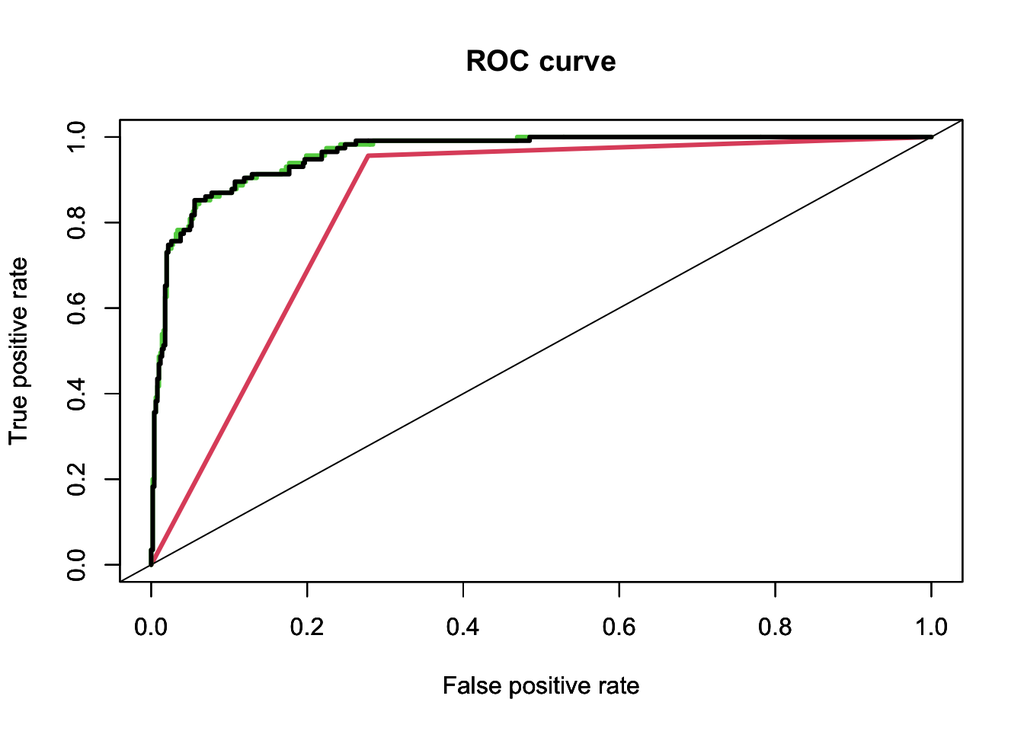

The RED is for the tree, GREEN is for the unpenalized logistic regression, and the BLACK is the logistic regression using LASSO.

Based on the results, we can see that the logistic and lasso regression showed much better performance. On the other hand, the tree did not perform as well. However, the logistic regression is much less interpretable than the tree, since for the tree, we have our splits of our variables which determine their importance and also the threshold at which they split. This gives the reader a better idea of how each variable influences the outcome variable. The tree is also more prone to overfitting. The tree can be trained on a small training dataset while the logistic regression requires a large dataset to work well.

The KNN classifier is not as appropriate as logistic regression since KNN doesn’t work with large datasets and it suffers from the curse of dimensionality where there are too many predictor variables. LDA and QDA are not appropriate since it has to assume that the observations follows a normal distribution, which it doesn’t. SVM does seem appropriate as there isn’t any cons to using SVM in this dataset with the exception that SVM performs well on high dimensional but small observational data, but logistic regression using LASSO so far is the most accurate thus the most appropriate way.

Also, some of our features have very high variance which means we have noisy features in our dataset, thus SVM and boosting would not work very well as they cannot handle noisy data very well.

# Question 19:

#### We will first try to use KNN CV to predict each county winner.

```
## [1] 0.1440129
```

#### For our 2nd Classification method, we will use Random Forests

```
## [1] 0.07605178
```

For our random forest, we get around a 7% error rate, which isn’t as bad as the tree/lasso/logistic, but not the best method to find the lowest error rate.

#### For our 3rd Classification method, we will use Boosting

```
## [1] 0.07443366
```

Similar to the random forest, our boosting gets us around 7% error rate.

#### For our 4th Classification method, we will use SVM

```
## [1] 0.06957929
```

SVM also gets us around 7% error rate

In conclusion, LASSO has the lowest error rate out of all our 7 machine learning models we used.

# Question 20:

#### We will first try to predict the number of total votes for each winner candidate using Lasso Linear Regression

#### MAE for lasso linear regression

```
## [1] 6779.006
```

Our mae isn’t too bad as it’s saying we’re on average around 6,779 people off from the actual count of how many each county winner got. We can run this on our test dataset including some counties to see how they compare.

```r
predictions <- round(predict(lasso_reg.mod, s = bestlam, newx = model.matrix(tot~., reg.te)[,-1]))

a <- cbind(election.reg[-idx.tr, ], predictions) %>% select(state, county, candidate, tot, s1)
a[c(1:10),]
```

```
##      state     county    candidate   tot    s1
## 1  alabama       bibb Donald Trump  7525  8342
## 2  alabama    bullock    Joe Biden  3446  2600
## 3  alabama   crenshaw Donald Trump  4864  3411
## 4  alabama     greene    Joe Biden  3884  2390
## 5  alabama      henry Donald Trump  6607 10870
## 6  alabama    marengo    Joe Biden  5488  8442
## 7  alabama montgomery    Joe Biden 64529 66044
## 8  alabama     morgan Donald Trump 39664 35161
## 9  alabama      perry    Joe Biden  3860  3681
## 10 alabama tallapoosa Donald Trump 14963 16500
```

It looks like our predictions aren’t too far off from the actual, with some weird, negative exceptions. This is completely different from the classification models since we’re not trying to predict the winner (Trump or Biden), but rather a number predicting how many votes someone got if they won the county. This would be a pretty good analysis if you were a manager for a candidate and you wanted to predict how many votes you would need to win a certain county (If elections were based on the winners of a county) in order to win the county as cost efficient and time efficient as possible.

# Question 21:

One thing that really confused me was the clustering part of our question. When I looked back on the dimension reduction, I felt like neither method (census clustering vs pca clustering) really worked, since Trump won a majority of counties, but no one else really won except for Trump, Biden or a few write-ins. Therefore, a barplot of the clustering should look like a lot of votes for one candidate, a moderate amount of votes for one candidate, and hardly any votes for the 3rd candidate, but both our barplots did not achieve this result.

We can visualize how our data ended up by classifying how our clusters performed. However, we must redo our cluster on our election.cl dataset instead of census.clean to successfully run our code (results changed but we should still see a similar pattern)

#### We can find how many clusters labeled as 1 belong to Trump and 2 to Biden to measure how many the clusters correctly predicted Trump or Biden

#### For Trump:

```
## [1] 0.7401942
```

The unsupervised clustering has correctly predicted that Trump was the winner 74% of the time.

#### For Biden:

```
## [1] 0.2782101
```

#### Overall Accuracy Score

```
## [1] 0.6633215
```

#### Now, we try the same thing with the PCA. Here we have majority labeled as ‘1’ and 2nd most as ‘7’ so we will set Trump according to 1 and Biden to 7.

#### Trump Accuracy Score

```
## [1] 0.6038835
```

The unsupervised PCA has correctly predicted that Trump was the winner 60% of the time.

#### Biden Accuracy Score

```
## [1] 0.2315175
```

#### Overall Accuracy Score

```
## [1] 0.541923
```

PCA Overall accuracy has a significant lower accuracy score than the census. Thus, despite lowering the amount of dimensions, it is not worth having a much lower accuracy score.

In conclusion, it’s a bit hard to predict on this dataset because most of the dataset have the county winner as Trump. If we’re getting such a low accuracy score for Biden, the clustering method is essentially just making guesses.

If we have a dataset that has an equal outcome split, we can more accurately determine which model or clustering method works best, albeit getting a lower accuracy score. If we consider that Trump has won a majority of the counties in general, our clustering accuracy score tells us that both the PCA and regular features are technically guessing and it isn’t really appropriate to use this method for both.